# Vis_simulation

Taotao Tan

12/23/2021

# Different sample size

#### The following conditions remain unchanged:

AFR_maf = 0.05

EUR_maf = 0.05

num_risk_alleles = 5

AFR_eff_size = 1

EUR_eff_size = 1

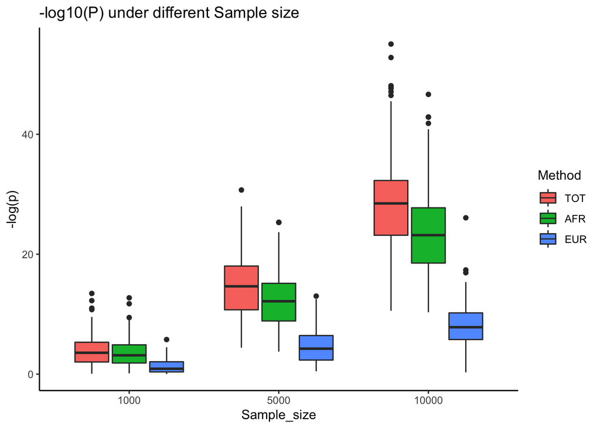

Notice when sample size gets larger, we tend to have smaller p value, which is expected. Here we set effect size of AFR = EUR, therefore we lose statistical power.

# Different AFR EUR effect size

#### The following conditions remain unchanged:

num_sample = 5000

AFR_maf = 0.05

EUR_maf = 0.05

num_risk_alleles = 5

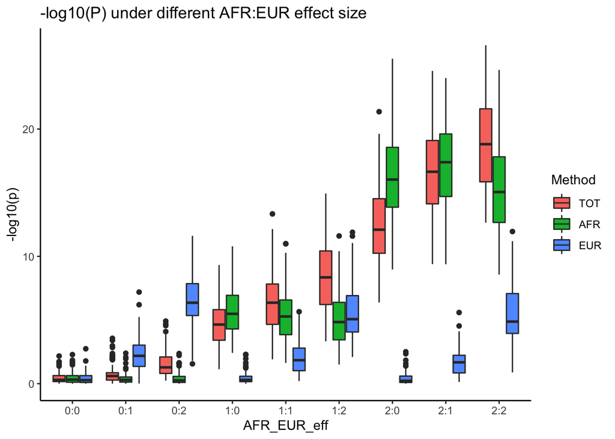

We vary the effect size of AFR and EUR, which is indicated in the x-axis (AFR:EUR). Notice when we have AFR effect size = EUR effect size, we tend to lose power. However, when they have different effect size, we tend to gain power. The most dramatic power gain is observed in AFR = 0, and EUR = 2.

# Different causal alleles

#### The following conditions remain unchanged:

num_sample = 5000

AFR_maf = 0.05

EUR_maf = 0.05

AFR_eff_size = 1

EUR_eff_size = 1

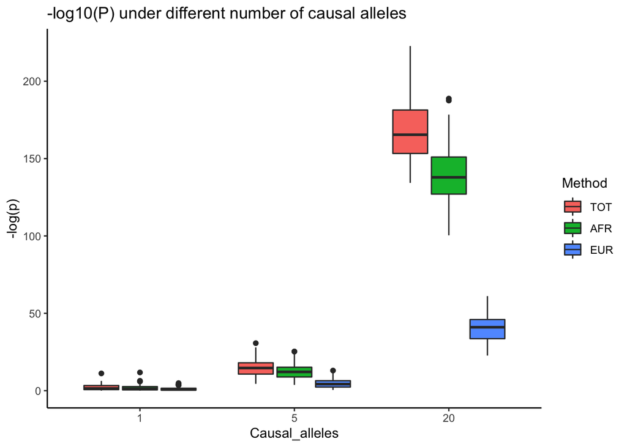

We simulate a gene with 100 variants, among 1/5/20 of them are causal variants (same direction). As expected, we gain power when there are more causal variants within a gene. We lose power here because AFR and EUR have the same effect size :(

# Different AFR/EUR minor allele frequency

#### The following conditions remain unchanged:

num_sample = 5000

num_risk_alleles = 5

AFR_eff_size = 1

EUR_eff_size = 1

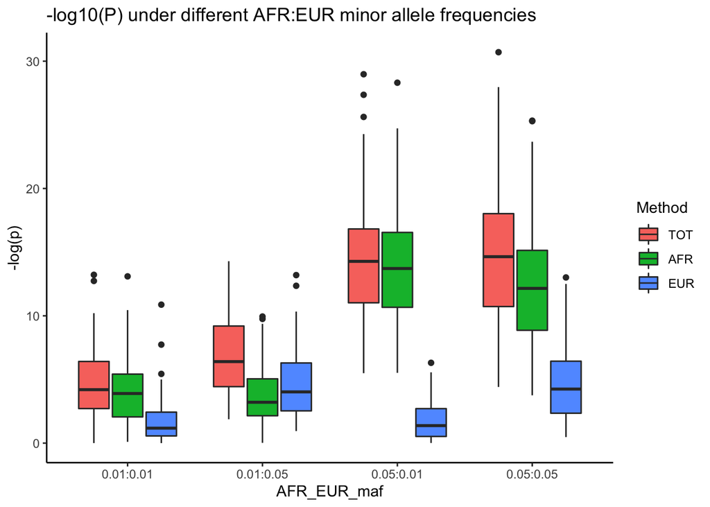

In general, if we have higher minor allele frequency, we tend to have better power.

### A summary:

Tractor burden test is meaningful when AFR and EUR causal variants have different effect size. We tend to gain power and make a more accurate estimate of the effect size. However, if their effect size is same/similar, a standard burden test is perfered.